# Unsupervised Campaign Segmentation

# K-Means Clustering

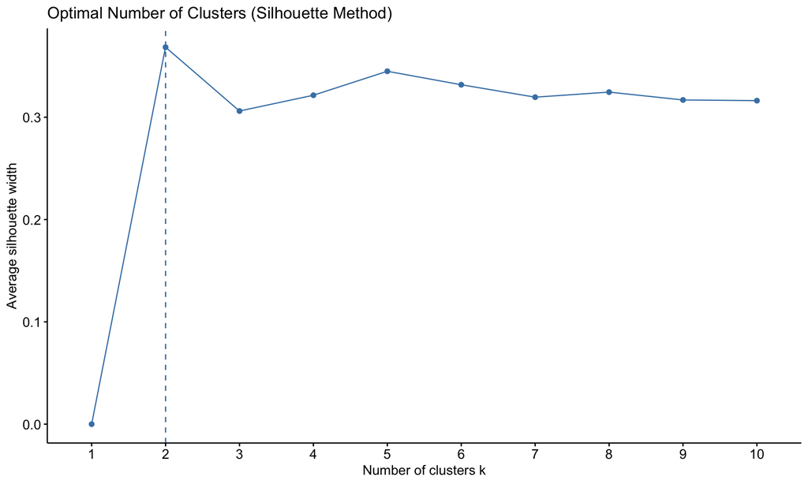

### Cluster Visualization

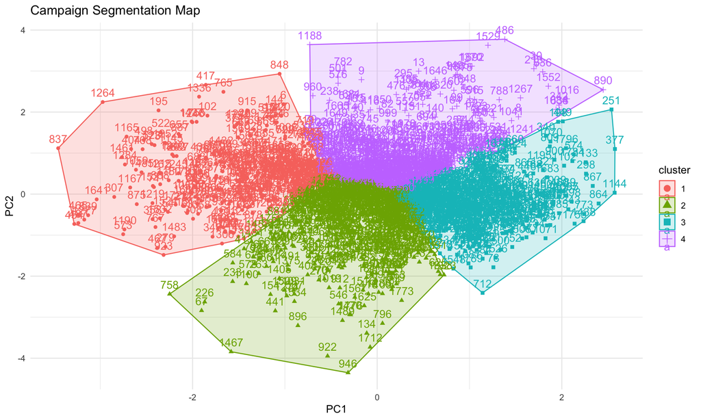

```r
set.seed(123)
k4 <- kmeans(pc_scores, centers = 4, nstart = 50)
fviz_cluster(k4, data = pc_scores) +
  theme_minimal() +
  ggtitle("Campaign Segmentation Map")
```

# Cluster Profiling & Insights

By merging the cluster assignments back to the original data, we can profile the average performance of each segment.

```r
ads_data$cluster <- as.factor(k4$cluster)

cluster_summary <- ads_data %>%
  group_by(cluster) %>%
  summarise(across(c(ad_spend, revenue, conversions, CTR, CPA, ROAS), mean), .groups = "drop")

knitr::kable(cluster_summary, digits = 2, caption = "Average Performance Metrics by Cluster")
```

Average Performance Metrics by Cluster

| cluster | ad_spend | revenue | conversions | CTR | CPA | ROAS |
| --- | --- | --- | --- | --- | --- | --- |
| 1 | 1129.63 | 3917.19 | 30.43 | 0.03 | 47.98 | 4.52 |
| 2 | 7722.71 | 13627.42 | 101.66 | 0.04 | 85.52 | 2.04 |
| 3 | 11539.40 | 63058.22 | 373.73 | 0.05 | 34.97 | 6.30 |
| 4 | 2916.22 | 32081.67 | 176.28 | 0.03 | 19.21 | 12.24 |

### Strategic Segments:

1. **Cluster 3 (Stars):** High-spend, high-revenue campaigns. These are the primary revenue drivers.
2. **Cluster 4 (Hidden Gems):** Low spend but extremely high ROAS (12.2). These are highly efficient and prime candidates for budget scaling.
3. **Cluster 2 (Bleeders):** High spend but very low ROAS and high CPA. These represent inefficient capital allocation.
4. **Cluster 1 (Core):** Low-budget, stable campaigns that provide consistent baseline performance.

# Hierarchical Validation

To verify the robustness of our segmentation, we performed **Hierarchical Clustering** using complete linkage.

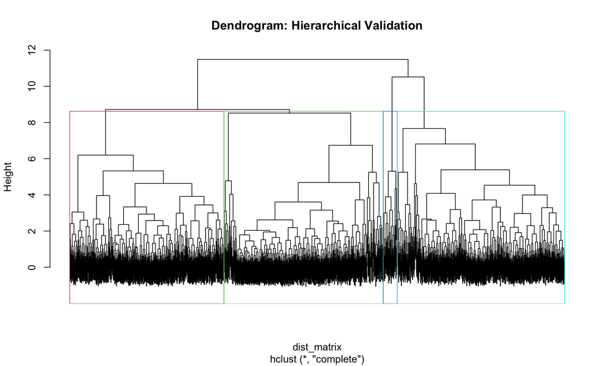

```r
data_scaled <- scale(data_clust)
dist_matrix <- dist(data_scaled)
hc_complete <- hclust(dist_matrix, method = "complete")

plot(hc_complete, main = "Dendrogram: Hierarchical Validation", labels = FALSE)
rect.hclust(hc_complete, k = 4, border = 2:5)
```

# Final Remarks

- The segmentation highlights two main latent dimensions: **campaign scale** and **campaign efficiency**.
- PCA confirms that most variability is captured by these orthogonal dimensions, justifying dimensionality reduction.
- K-Means identifies four structurally distinct segments, suggesting meaningful heterogeneity across the dataset.
- The results should be treated as exploratory patterns, providing a data-driven foundation for budget reallocation and creative optimization.